# What factors affect a loan’s outcome status?

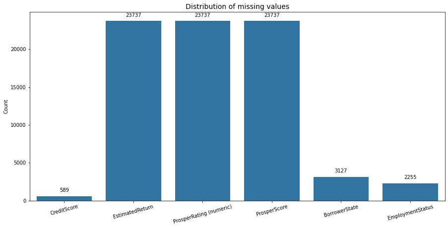

```python
#counting missing values plot
plt.figure(figsize=[15,7])
color_base=sb.color_palette()[0]
sb.barplot(na_counts.index.values, na_counts,color=color_base)
plt.xticks(rotation=15)
plt.ylabel('Count')
plt.title('Distribution of missing values',fontsize=14)
# Logic to print value on each bar
for i in range (na_counts.shape[0]):
    count = na_counts[i]
    plt.text(i, count+1100, count, ha = 'center', va='top')
```

### What is the structure of your dataset?

There are 84853 loan in the dataset with 15 features (CreditScore', 'Term', 'LoanStatus', 'BorrowerAPR', 'BorrowerRate', 'LenderYield', 'EstimatedReturn', 'ProsperRating (numeric)', 'ProsperScore', 'ListingCategory (numeric)', 'BorrowerState', 'EmploymentStatus', ''IncomeRange'', 'LoanOriginalAmount', 'Investors'). Most variables are numeric and categorical.

### What is/are the main feature(s) of interest in your dataset?

I'm most interested in figuring out what features are best for predicting the loan’s outcome status.

### What features in the dataset do you think will help support your investigation into your feature(s) of interest?

I expect that credit score will have the strongest effect on each Loan outcome status:the more stable Employment, the higher the loan outcome status.

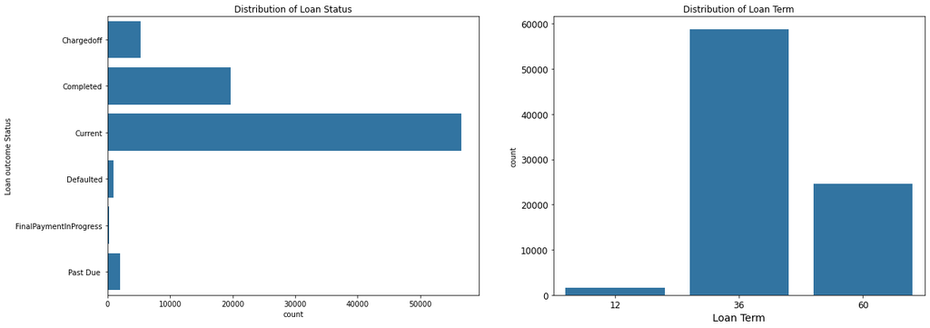

```python
plt.figure(figsize=[20,7])
plt.subplot(1,2,1)
base_color=sb.color_palette()[0]
sb.countplot(data=df, y='LoanStatus', color=base_color);
#plt.xscale('log')
#plt.xticks([10, 100, 1000, 10000,50000], [10, '100', '1000', '10000','50000'])
plt.ylabel('Loan outcome Status')
plt.title("Distribution of Loan Status");
plt.subplot(1,2,2)
sb.countplot(data = df, x = 'Term', color = base_color);
plt.xlabel('Loan Term',fontsize = 14);
plt.xticks(fontsize = 12);
plt.yticks(fontsize = 12);
plt.title("Distribution of Loan Term");
plt.savefig("Dist of loan status and term.png")
```

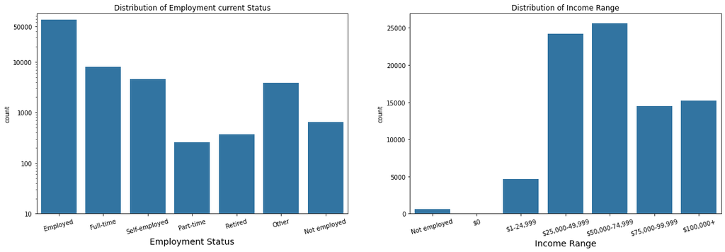

```python
plt.figure(figsize=[20,6])
plt.subplot(1,2,1)
base_color=sb.color_palette()[0]
sb.countplot(data=df, x='EmploymentStatus', color=base_color);
plt.yscale('log')
plt.yticks([10, 100, 1000, 10000,50000], [10, '100', '1000', '10000','50000'])
plt.title("Distribution of Employment current Status");
plt.xlabel('Employment Status', fontsize = 14)
plt.xticks(rotation=15)
plt.subplot(1,2,2)
sb.countplot(data=df, x='IncomeRange', color=base_color);
plt.xticks(rotation=15)
plt.xlabel('Income Range', fontsize = 14)
plt.title("Distribution of Income Range");
plt.savefig("Dist of loan employment status and Income Range.png")
```

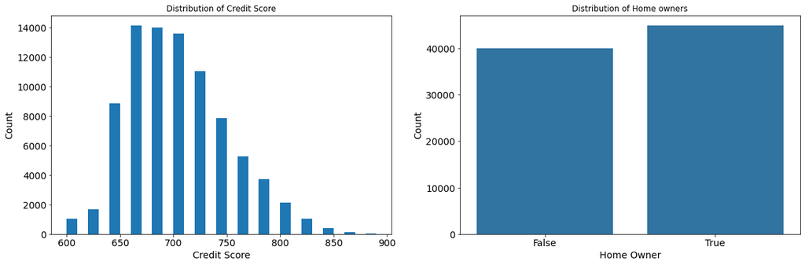

```python
plt.figure(figsize = [20, 6])
plt.subplot(1,2,1)
bins=np.arange(600,890+10,10)
plt.hist(data = df, x = 'CreditScore', bins = bins);
plt.xticks(fontsize =14);
plt.yticks(fontsize =14);
plt.xlabel('Credit Score', fontsize = 14);
plt.ylabel('Count', fontsize = 14);
plt.title('Distribution of Credit Score');

plt.subplot(1,2,2)
sb.countplot(data = df, x = 'IsBorrowerHomeowner', color = base_color);
plt.xlabel('Home Owner', fontsize = 14);
plt.ylabel('Count', fontsize = 14);
plt.xticks(fontsize =14);
plt.yticks(fontsize =14);
plt.title("Distribution of Home owners");
plt.savefig("Distributions of Credit Score and Home owners.png")
```

[figure not shown]

```python
bins=np.arange(-.1,0.3+.025,0.015)
plt.figure(figsize=[20,7])
plt.subplot(1,2,2)
plt.hist(data = df, x = 'EstimatedReturn', bins = bins);
#plt.xlim((0.0,0.2))
plt.yscale('log')
plt.yticks([1, 10, 100,1000,10000], [1,'10', '100', '1000', '10000'],fontsize=14)
plt.xticks(fontsize =14);
plt.xlabel('Credit Score', fontsize = 14);
plt.ylabel('Count', fontsize = 14);
plt.title('Distribution of Estimated Return in Log Scale');

plt.subplot(1,2,1)
plt.hist(data = df, x = 'EstimatedReturn', bins = bins);
plt.xlim((0.0,0.2))
#plt.yscale('log')
plt.xticks(fontsize =14);
plt.yticks(fontsize =14);
plt.xlabel('Credit Score', fontsize = 14);
plt.ylabel('Count', fontsize = 14);
plt.title('Distribution of Estimated return');
plt.savefig("Distribution of Estimated return.png")
```

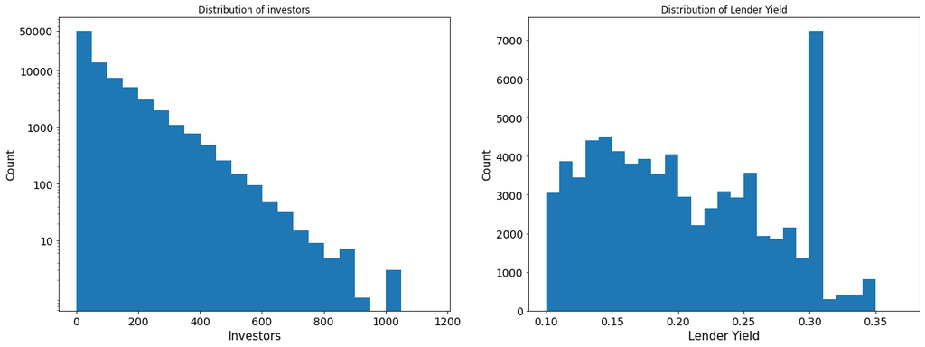

```python
plt.figure(figsize=[20,7])
plt.subplot(1,2,1)
bins=np.arange(1,1200,50)
plt.hist(data = df, x = 'Investors', bins = bins);
plt.yscale('log')
plt.yticks([10, 100, 1000, 10000,50000], [10, '100', '1000', '10000','50000'])
#plt.xlim((0,250))
plt.xticks(fontsize =14);
plt.yticks(fontsize =14);
plt.xlabel('Investors', fontsize = 15);
plt.ylabel('Count', fontsize = 14);
plt.title('Distribution of investors');
plt.subplot(1,2,2)
bins=np.arange(0.1,0.35+.025,0.01)
plt.hist(data = df, x = 'LenderYield',bins=bins);
#plt.xlim((0,250))
plt.xticks(fontsize =14);
plt.yticks(fontsize =14);
plt.xlabel('Lender Yield', fontsize = 15);
plt.ylabel('Count', fontsize = 14);
plt.title('Distribution of Lender Yield');
plt.savefig("Distributions of Inverstors and Lender Yield.png")
```

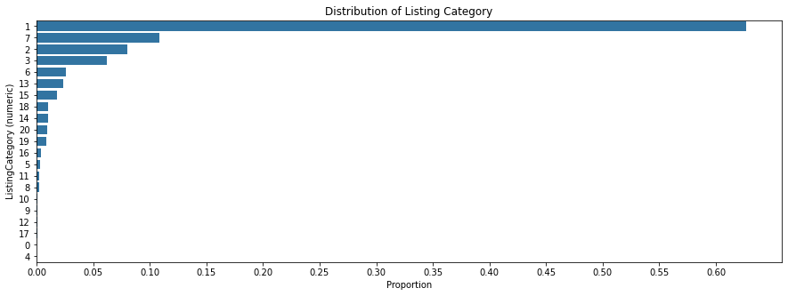

```python
list_order =df['ListingCategory (numeric)'].value_counts().index
num_lists = df.shape[0]
max_count = df['ListingCategory (numeric)'].value_counts().max()
max_prop = max_count / num_lists

# generate tick mark locations and names
tick_props = np.arange(0, max_prop, 0.05)
tick_names = ['{:0.2f}'.format(v) for v in tick_props]
plt.figure(figsize=[15, 5]);
sb.countplot(data = df, y = 'ListingCategory (numeric)', color = sb.color_palette()[0], order = list_order)
plt.xticks(tick_props * num_lists, tick_names);
plt.xlabel('Proportion');
plt.title('Distribution of Listing Category');
plt.savefig("Distributions of Listing Category.png")
```

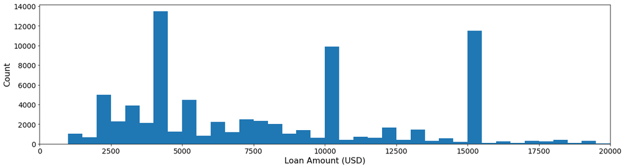

```python
plt.figure(figsize = [20, 5])
plt.hist(data = df, x ='LoanOriginalAmount', bins= np.arange(0, df['LoanOriginalAmount'].max()+500,500));
plt.xlabel('Loan Amount (USD)', fontsize = 16);
plt.xlim((0,20000))
plt.ylabel('Count', fontsize = 16);
plt.xticks(fontsize = 14);
plt.yticks(fontsize = 14);
plt.savefig("Distributions of Loan Amount.png")
```

# Bivariate Exploration of Data

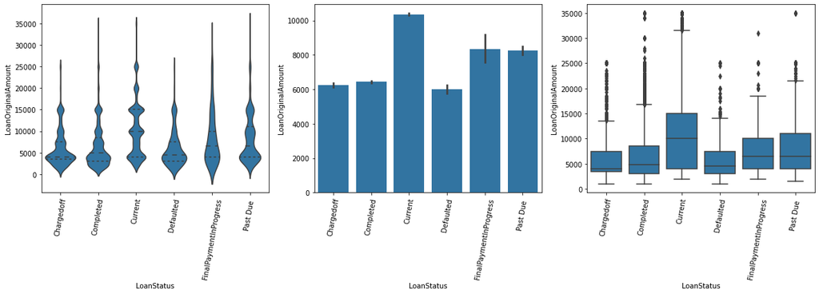

```python
plt.figure(figsize=[20,5])
plt.subplot(1,3,1)
sb.violinplot(data=df,x='LoanStatus',y='LoanOriginalAmount',color=base_color,inner='quartile');
plt.xticks(rotation=80);
plt.subplot(1,3,2)
sb.barplot(data=df,x='LoanStatus',y='LoanOriginalAmount',color=base_color);
plt.xticks(rotation=80);
plt.subplot(1,3,3)
sb.boxplot(data=df,x='LoanStatus',y='LoanOriginalAmount',color=base_color);
plt.xticks(rotation=80);
plt.savefig("Relation between Loan Status and amount.png")
```

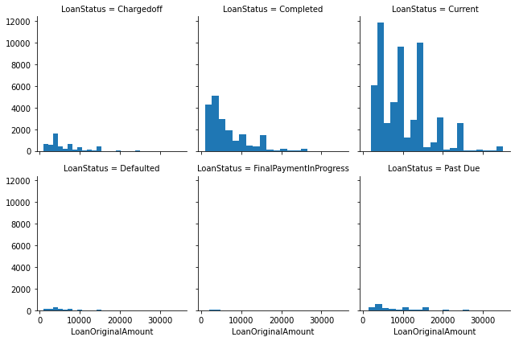

```python
g=sb.FacetGrid(data=df,col='LoanStatus',col_wrap=3)
g.map(plt.hist,'LoanOriginalAmount',bins=20);
plt.savefig("Relation2 between Loan Status and amount.png")
```

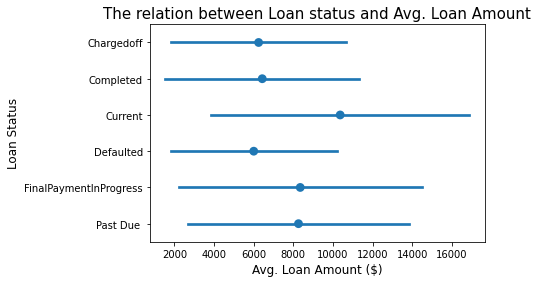

```python
sb.pointplot(data=df,y='LoanStatus',x='LoanOriginalAmount',ci='sd',linestyles="");
plt.xlabel('Avg. Loan Amount ($)',fontsize=12);
plt.ylabel('Loan Status',fontsize=12);
plt.title('The relation between Loan status and Avg. Loan Amount',fontsize=15);
```

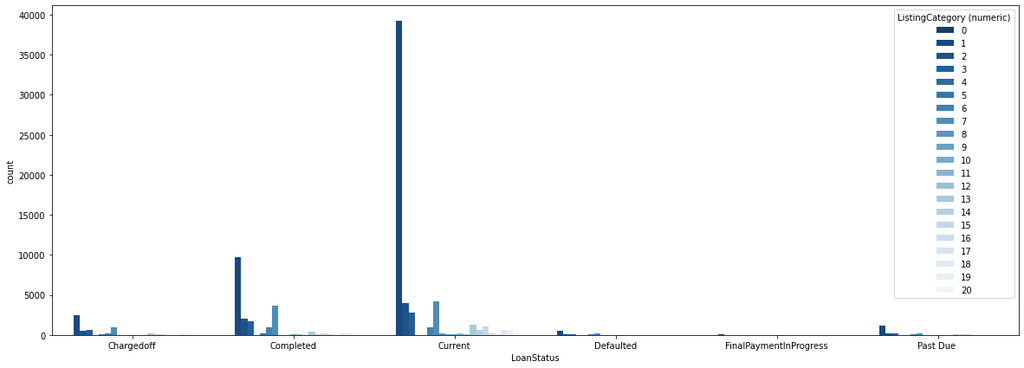

```python
plt.figure(figsize=[20,7])
sb.countplot(data = df, x = 'LoanStatus', hue = 'ListingCategory (numeric)',palette='Blues_r');
plt.savefig("Relation between Loan Status and Listing Category.png")
```

[figure not shown]

```python
plt.figure(figsize=[10,5])
sb.heatmap(ct_counts,cmap='viridis_r');
plt.title('The effect of Listing Category on the loan Status',fontsize=14);
plt.savefig("Relation2 between Loan Status and Listing Category.png")
```

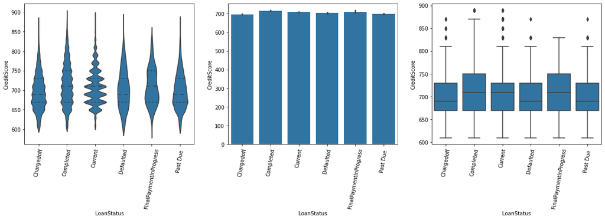

```python
plt.figure(figsize=[20,5])
plt.subplot(1,3,1)
sb.violinplot(data=df,x='LoanStatus',y='CreditScore',color=base_color,inner='quartile');
plt.xticks(rotation=80);
plt.subplot(1,3,2)
sb.barplot(data=df,x='LoanStatus',y='CreditScore',color=base_color);
plt.xticks(rotation=80);
plt.subplot(1,3,3)
sb.boxplot(data=df,x='LoanStatus',y='CreditScore',color=base_color);
plt.xticks(rotation=80);
plt.savefig("Relation between Loan Status and Credit Score.png")
```

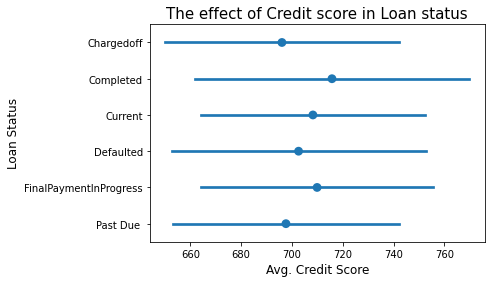

```python
sb.pointplot(data=df,y='LoanStatus',x='CreditScore',ci='sd',linestyles="");
plt.xlabel('Avg. Credit Score',fontsize=12);
plt.ylabel('Loan Status',fontsize=12);
plt.title('The effect of Credit score in Loan status',fontsize=15);
plt.savefig("The effect of Credit score in Loan status.png")
```

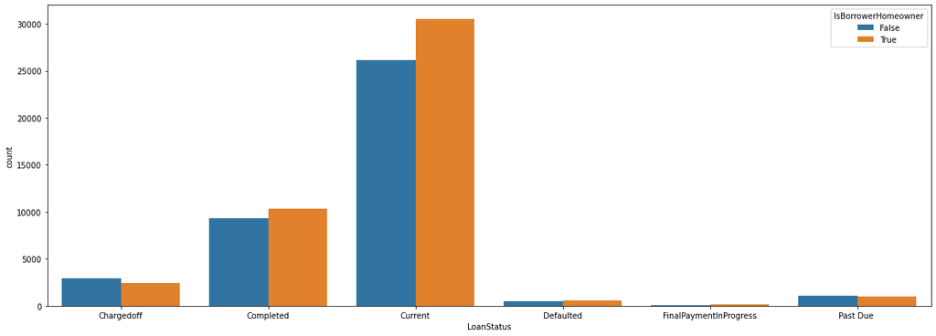

```python
plt.figure(figsize=[20,7])
sb.countplot(data = df, x = 'LoanStatus', hue = 'IsBorrowerHomeowner');
plt.savefig("The effect of Homeowner in Loan status.png")
```

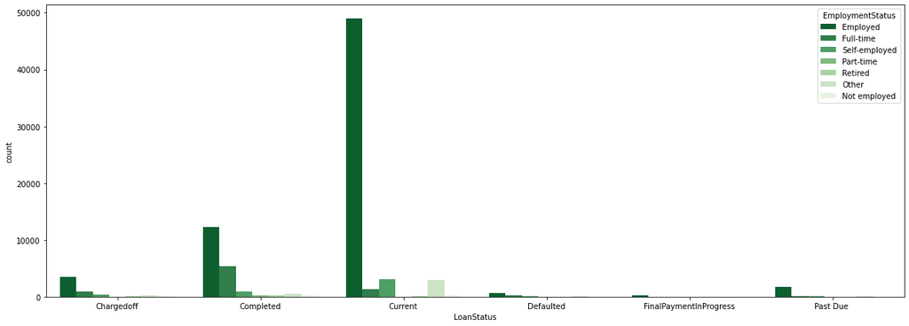

```python
plt.figure(figsize=[20,7])
sb.countplot(data = df, x = 'LoanStatus', hue = 'EmploymentStatus', palette='Greens_r');
plt.savefig("The effect of Employment Status in Loan status(1).png")
```

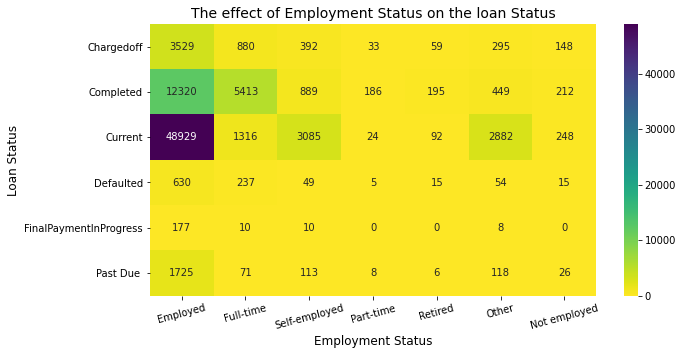

```python
ct_counts = df.groupby(['LoanStatus', 'EmploymentStatus']).size()
ct_counts = ct_counts.reset_index(name='count')
ct_counts = ct_counts.pivot(index = 'LoanStatus', columns = 'EmploymentStatus', values = 'count')
plt.figure(figsize=[10,5])
sb.heatmap(ct_counts,cmap='viridis_r',annot=True,fmt='d');
plt.xlabel('Employment Status',fontsize=12)
plt.ylabel('Loan Status',fontsize=12)
plt.title('The effect of Employment Status on the loan Status',fontsize=14);
plt.xticks(rotation=15);
plt.savefig("The effect of Employment Status in Loan status(2).png")
```

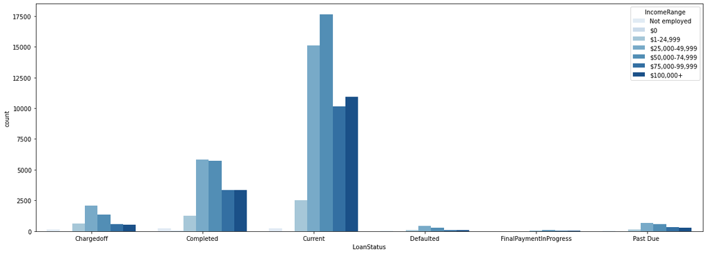

```python
plt.figure(figsize=[20,7])
sb.countplot(data = df, x = 'LoanStatus', hue = 'IncomeRange',palette='Blues');
plt.savefig("The effect of Income Range in the Loan Status.png")
```

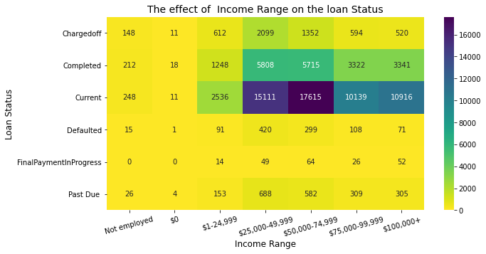

```python
ct_counts = df.groupby(['LoanStatus', 'IncomeRange']).size()
ct_counts = ct_counts.reset_index(name='count')
ct_counts = ct_counts.pivot(index = 'LoanStatus', columns = 'IncomeRange', values = 'count')
plt.figure(figsize=[10,5])
sb.heatmap(ct_counts,cmap='viridis_r',annot=True,fmt='d');
plt.xlabel('Income Range',fontsize=12)
plt.ylabel('Loan Status',fontsize=12)
plt.title('The effect of  Income Range on the loan Status',fontsize=14);
plt.xticks(rotation=15);
plt.savefig("The effect of Income Range in the Loan Status2.png")
```

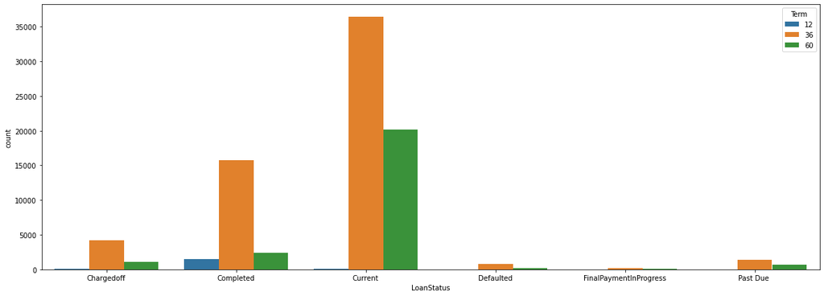

```python
plt.figure(figsize=[20,7])
sb.countplot(data = df, x = 'LoanStatus', hue = 'Term');
plt.savefig("The effect Term in the Loan Status2.png")
```

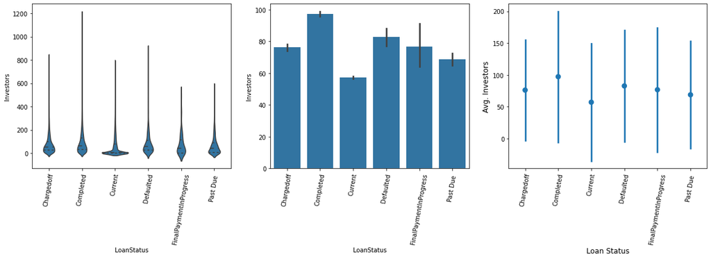

```python
plt.figure(figsize=[20,5])
plt.subplot(1,3,1)
sb.violinplot(data=df,x='LoanStatus',y='Investors',color=base_color,inner='quartile');
plt.xticks(rotation=80);
plt.subplot(1,3,2)
sb.barplot(data=df,x='LoanStatus',y='Investors',color=base_color);
plt.xticks(rotation=80);
plt.subplot(1,3,3)
sb.pointplot(data=df,x='LoanStatus',y='Investors',ci='sd',linestyles="");
plt.xticks(rotation=80);
plt.ylabel('Avg. Investors',fontsize=12);
plt.xlabel('Loan Status',fontsize=12);
plt.savefig("Relation between Loan Status and No. of Investors.png")
```

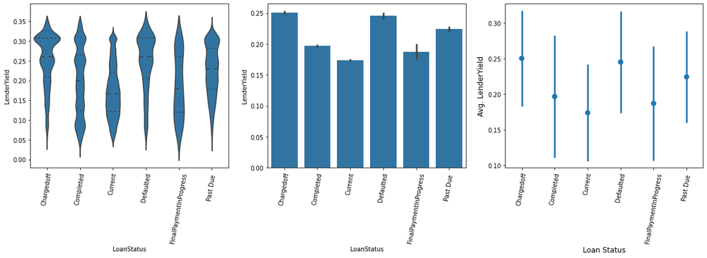

```python
plt.figure(figsize=[20,5])
plt.subplot(1,3,1)
sb.violinplot(data=df,x='LoanStatus',y='LenderYield',color=base_color,inner='quartile');
plt.xticks(rotation=80);
plt.subplot(1,3,2)
sb.barplot(data=df,x='LoanStatus',y='LenderYield',color=base_color);
plt.xticks(rotation=80);
plt.subplot(1,3,3)
sb.pointplot(data=df,x='LoanStatus',y='LenderYield',ci='sd',linestyles="");
plt.xticks(rotation=80);
plt.ylabel('Avg. LenderYield',fontsize=12);
plt.xlabel('Loan Status',fontsize=12);
plt.savefig("Relation between Loan Status and Lender Yield.png")
```

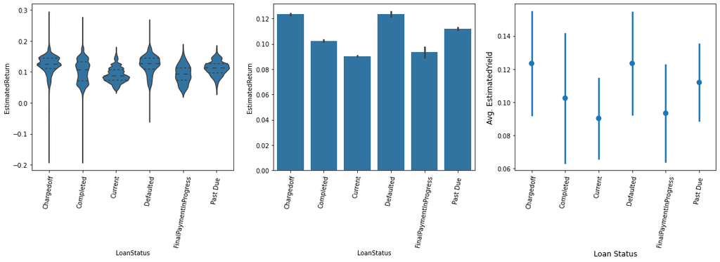

```python
plt.figure(figsize=[20,5])
plt.subplot(1,3,1)
sb.violinplot(data=df,x='LoanStatus',y='EstimatedReturn',color=base_color,inner='quartile');
plt.xticks(rotation=80);
plt.subplot(1,3,2)
sb.barplot(data=df,x='LoanStatus',y='EstimatedReturn',color=base_color);
plt.xticks(rotation=80);
plt.subplot(1,3,3)
sb.pointplot(data=df,x='LoanStatus',y='EstimatedReturn',ci='sd',linestyles="");
plt.xticks(rotation=80);
plt.ylabel('Avg. EstimatedYield',fontsize=12);
plt.xlabel('Loan Status',fontsize=12);
plt.savefig("Relation between Loan Status and Estimated Return Rate.png")
```

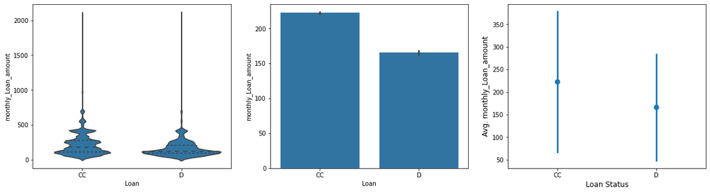

```python
#Feature Engineering
df['monthly_Loan_amount']=df.LoanOriginalAmount/df.Term.astype(int)
plt.figure(figsize=[20,5])
plt.subplot(1,3,1)
sb.violinplot(data=df,x='Loan',y='monthly_Loan_amount',color=base_color,inner='quartile');
plt.subplot(1,3,2)
sb.barplot(data=df,x='Loan',y='monthly_Loan_amount',color=base_color);
plt.subplot(1,3,3)
sb.pointplot(data=df,x='Loan',y='monthly_Loan_amount',ci='sd',linestyles="");
plt.ylabel('Avg. monthly_Loan_amount',fontsize=12);
plt.xlabel('Loan Status',fontsize=12);
plt.savefig("Relation between Loan Status and Monthly Laon amount.png")
```

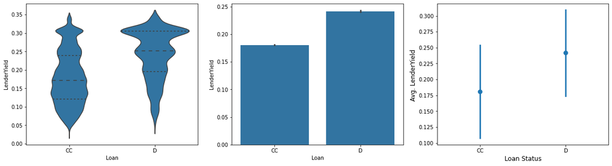

```python
plt.figure(figsize=[20,5])
plt.subplot(1,3,1)
sb.violinplot(data=df,x='Loan',y='LenderYield',color=base_color,inner='quartile');
plt.subplot(1,3,2)
sb.barplot(data=df,x='Loan',y='LenderYield',color=base_color);
plt.subplot(1,3,3)
sb.pointplot(data=df,x='Loan',y='LenderYield',ci='sd',linestyles="");
plt.ylabel('Avg. LenderYield ',fontsize=12);
plt.xlabel('Loan Status',fontsize=12);
plt.savefig("Relation between Loan Status and Interest Rate.png")
```

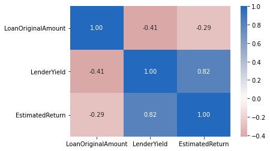

```python
#correlation between Loan Amount,Lender Yield and Estimated Return
sb.heatmap(df[['LoanOriginalAmount','LenderYield','EstimatedReturn']].corr(), annot = True, fmt = '.2f', cmap = 'vlag_r', center = 0);
plt.savefig("The Correlation between Loan Amount, Lender Yield and Estimated Return.png")
```

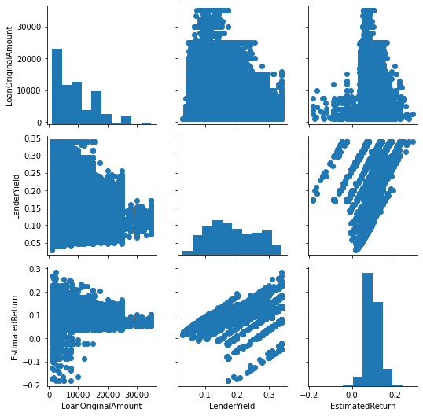

```python
g = sb.PairGrid(data = df, vars = ['LoanOriginalAmount', 'LenderYield', 'EstimatedReturn'])
g.map_diag(plt.hist)
g.map_offdiag(plt.scatter);
plt.savefig("The Scatter plots between Loan Amount, Lender Yield and Estimated Return.png")
```

# MulitVariate Exploration of The Data

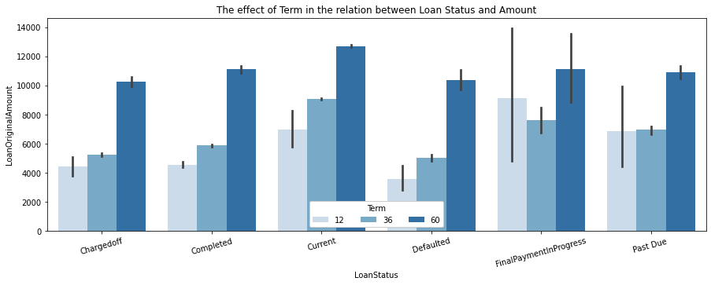

```python
plt.figure(figsize=[15,5])
ax = sb.barplot(data = df, x = 'LoanStatus', y = 'LoanOriginalAmount', hue = 'Term',palette='Blues')
ax.legend(loc = 8, ncol = 3, framealpha = 1, title = 'Term')
plt.xticks(rotation=15);
plt.title('The effect of Term in the relation between Loan Status and Amount');
plt.savefig("The effect of Term in the relation between Loan Status and Amount.png")
```

-The bigger loan amount tends to have higher months term.

-The variability is higher in lower months term.

-The Current,Completed and FinalPaymentInProgress Status are the higher Loan amount with higher months term.

[figure not shown]

```python
def mean_poly(x, y, bins = 10, **kwargs):
    """ Custom adapted line plot code. """
    # set bin edges if none or int specified
    if type(bins) == int:
        bins = np.linspace(x.min(), x.max(), bins+1)
    bin_centers = (bin_edges[1:] + bin_edges[:-1]) / 2

    # compute counts
    data_bins = pd.cut(x, bins, right = False,
                       include_lowest = True)
    means = y.groupby(data_bins).mean()

    # create plot
    plt.errorbar(x = bin_centers, y = means, **kwargs)

bin_edges = np.arange(1,250,10)
g = sb.FacetGrid(data = df, hue = 'LoanStatus', size = 5)
g.map(mean_poly, "Investors", "EstimatedReturn", bins = bin_edges)
g.set_ylabels('mean(loan Amount)');
g.add_legend();
#plt.xscale('log')
```

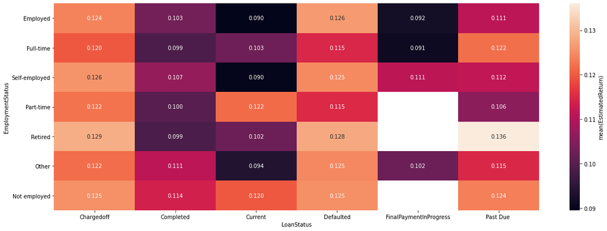

```python
plt.figure(figsize=[20,7])
Loan_means = df.groupby(['LoanStatus', 'EmploymentStatus']).mean()['EstimatedReturn']
Loan_means = Loan_means.reset_index(name = 'EstimatedReturn_avg')
Loan_means = Loan_means.pivot(index = 'EmploymentStatus', columns = 'LoanStatus',
                            values = 'EstimatedReturn_avg')
sb.heatmap(Loan_means, annot = True, fmt = '.3f',
           cbar_kws = {'label' : 'mean(EstimatedReturn)'});
plt.savefig("The effect of Estimated Return Rate in the relation between Loan and Employment Status .png")
```

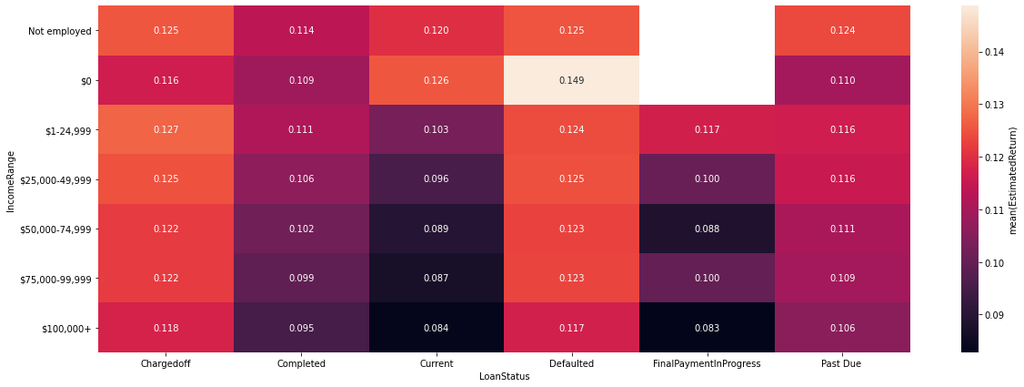

```python
plt.figure(figsize=[20,7])
Loan_means = df.groupby(['LoanStatus', 'IncomeRange']).mean()['EstimatedReturn']
Loan_means = Loan_means.reset_index(name = 'EstimatedReturn_avg')
Loan_means = Loan_means.pivot(index = 'IncomeRange', columns = 'LoanStatus',
                            values = 'EstimatedReturn_avg')
sb.heatmap(Loan_means, annot = True, fmt = '.3f',
           cbar_kws = {'label' : 'mean(EstimatedReturn)'});
plt.savefig("The effect of Estimated Return Rate in the relation between Loan Status and Income Range .png")
```

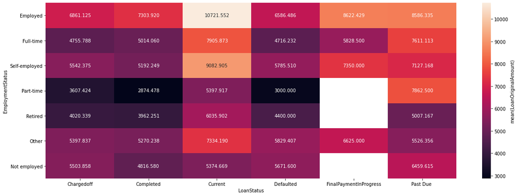

```python
plt.figure(figsize=[20,7])
Loan_means = df.groupby(['LoanStatus', 'EmploymentStatus']).mean()['LoanOriginalAmount']
Loan_means = Loan_means.reset_index(name = 'LoanOriginalAmount_avg')
Loan_means = Loan_means.pivot(index = 'EmploymentStatus', columns = 'LoanStatus',
                            values = 'LoanOriginalAmount_avg')
sb.heatmap(Loan_means, annot = True, fmt = '.3f',
           cbar_kws = {'label' : 'mean(LoanOriginalAmount)'});
plt.savefig("The effect of Loan Amount in the Relation between Loan Status and Income Range.png")
```

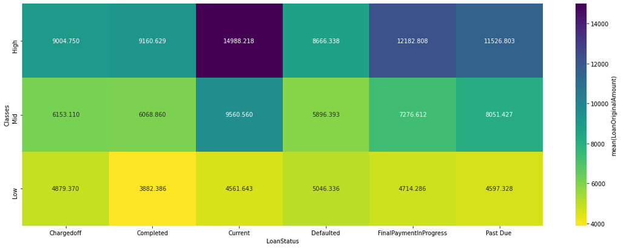

```python
plt.figure(figsize=[20,7])
Loan_means = df.groupby(['LoanStatus', 'Classes']).mean()['LoanOriginalAmount']
Loan_means = Loan_means.reset_index(name = 'LoanOriginalAmount_avg')
Loan_means = Loan_means.pivot(index = 'Classes', columns = 'LoanStatus',
                            values = 'LoanOriginalAmount_avg')
sb.heatmap(Loan_means, annot = True, fmt = '.3f',cmap='viridis_r',
           cbar_kws = {'label' : 'mean(LoanOriginalAmount)'});
plt.savefig("The effect of Loan Amount in the Relation between Loan Status and Social Classes.png")
```

As we see, The High class takes high Loan Amount in average and it goes down as we go to lower income rate

most of High class --> Current Status then final payment in progress

most of Mid class --> Current Status then past due.

most of low class --> Defaulted Status then charged off.

### Some of the relationships you observed in this part of the investigation. Were there features that strengthened each other in terms of looking at your feature(s) of interest?

- The Social class effect the Loan status directly and we can see that from the IncomeRange and EmploymentStatus
- The amount of the loan effect the loan status too.
- The interest rate is related to the estimated return and effect the loan status.